# Bonanza Hares

Jacob Weverka

11/16/2020

# 1 Introduction

Read in data

```r
hares_data = read_csv(here::here("data/bonanza_hares.csv"))
```

# 2 Data and Analyses Overview

The following analysis will focus on snowshoe hare data provided by [Knut et al (2017)](https://doi.org/10.6073/pasta/03dce4856d79b91557d8e6ce2cbcdc14). I will begin analysis by examining the number of juvenile snowshoe hares captured through time during the course of the study. I will then compare mean body sizes of male and female juvenile hares. I will then examine relationships between hind foot lenght and body weight in juvenile snowshoe hares.

Clean up data (dates)

```r
hares = hares_data %>%
  mutate(date = lubridate::mdy(date)) %>%
  mutate(year = lubridate::year(date))

juveniles = hares %>%
  filter(age == "j") %>%
  mutate(sex = replace_na(sex, "Unknown"))
```

# 3 Exploratory findings

## 3.1 Exploring counts of juvenile hares

Calculate number of juveniles and number of traps each year.

```r
jhares = hares %>%
  filter(age == "j") %>%
  group_by(year) %>%
  count(name = "juveniles")

traps = hares %>%
  group_by(year) %>%
  summarise(ntraps = n_distinct(trap))

juv_hares = jhares %>%
  full_join(traps, by = "year")
```

Make plot of juvenile captures by year

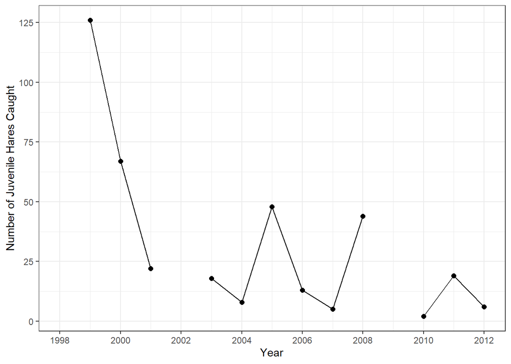

Figure 3.1: Juvenile hares caught in traps during each year of study

```r
ggplot(juv_hares, aes(x = year, y = juveniles)) +
  geom_point(size = 2) +
  geom_line() +
  xlab("Year") +
  ylab("Number of Juvenile Hares Caught") +
  theme_bw() +
  scale_x_continuous(breaks = seq(1998, 2012, 2))
```

## 3.2 Vizualizing juvenile hare weights

Here, we’re creating a dataframe of summary statistics for hare weights at each site and of each sex.

```r
juv_weight_sum = juveniles %>%
  group_by(sex, grid) %>%
  summarise(mean_weight = mean(weight, na.rm = TRUE), sd_weight = sd(weight, na.rm = TRUE)) %>%
  drop_na(sd_weight)
```

Now, we’ll plot hare weights by sex and by site, with summary statistics overlayed.

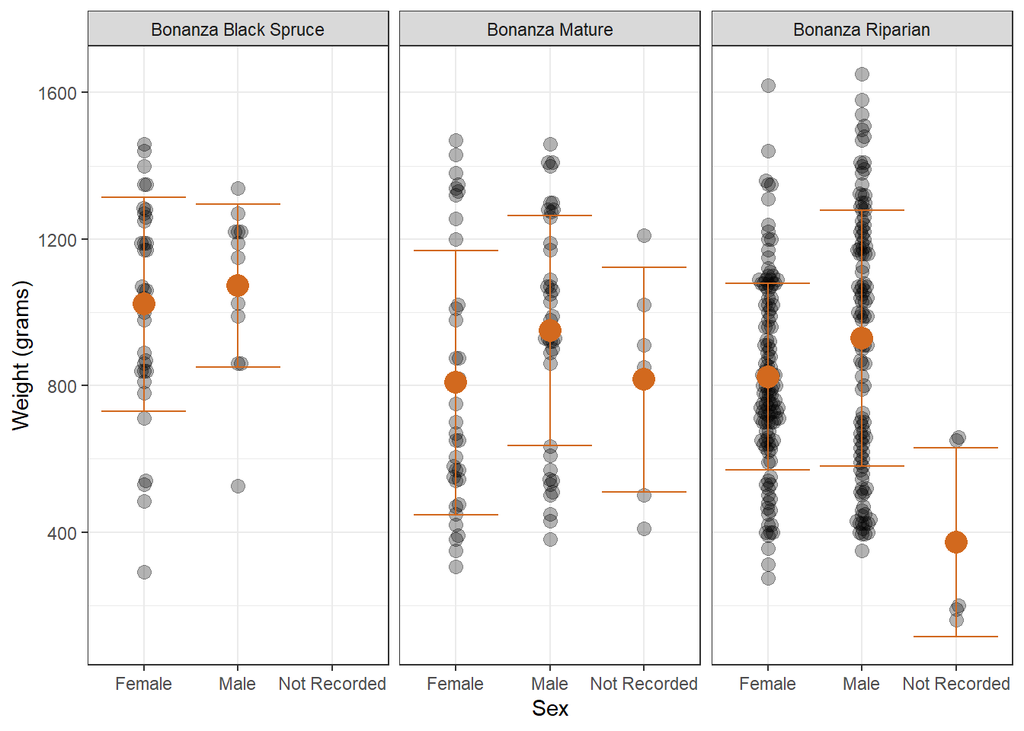

Figure 3.2: Weights of juvenile hares by sex in each study site. Values shown in gray are individual hare weight. Mean weights are shown in brown, with one standard deviation represented by the error bar.

```r
grid_labs = c("Bonanza Black Spruce", "Bonanza Mature", "Bonanza Riparian")
names(grid_labs) = c("bonbs", "bonmat", "bonrip")

ggplot() +
  geom_beeswarm(data = juveniles, aes(x = sex, y = weight),
                size = 3,
                alpha = 0.3) +
  geom_point(data = juv_weight_sum,
             aes(x = sex, y = mean_weight),
             color = "chocolate",
             size = 5) +
  facet_wrap(.~grid,
             labeller = labeller(grid = grid_labs)) +
  geom_errorbar(data = juv_weight_sum,
                aes(x = sex,
                    ymin = mean_weight - sd_weight,
                    ymax = mean_weight + sd_weight),
                color = "chocolate") +
  scale_x_discrete(name = "Sex",
                   labels = c("f" = "Female", "m" = "Male", "Unknown" = "Not Recorded")) +
  ylab("Weight (grams)") +
  theme_bw()
```

From this graph, it appears that male juvenile hares had a higher mean body weight than females at each site. Still, it is not clear whether this is a meaningful or statistically significant difference, since the difference in means is less than a standard deviation for each site.

## 3.3 Weight comparison between female and male hares

Here is a finalized table containing the mean, standard deviation, and sample size of juvenile male and female hares

```r
sex_summary = juveniles %>%
  group_by(sex) %>%
  summarise(mean_weight = mean(weight, na.rm = TRUE), sd_weight = sd(weight, na.rm = TRUE), n()) %>%
  mutate(sex = case_when(
    sex == "f" ~ "Female",
    sex == "m" ~ "Male",
    sex == "Unknown" ~ "Unknown"
  ))

knitr::kable(sex_summary, col.names = c("Sex", "Mean Weight", "Standard Deviation of Weight", "Sample Size"), caption = "Means and standard deviations of body weight for each sex of snowshoe hare")
```

Table 3.1: Means and standard deviations of body weight for each sex of snowshoe hare

| Sex | Mean Weight | Standard Deviation of Weight | Sample Size |
| --- | --- | --- | --- |
| Female | 855.3909 | 292.2526 | 200 |
| Male | 945.8589 | 333.2151 | 163 |
| Unknown | 614.5455 | 357.5853 | 15 |

Exploratory graphs to examine normality (graphs not shown, but code included)

```r
ggplot(juveniles, aes(x = weight)) +
  geom_histogram() +
  facet_wrap(~sex)

ggplot(juveniles, aes(sample = weight)) +
  geom_qq() +
  facet_wrap(~sex)
```

The distribution of body weights does not appear exactly normal, based on the histograms and the qqplots. Still, the sample size is high enough that we should still be able to use parametric tests to look at differences between means.

Creating separate vectors for female and male weights

```r
juv_males = juveniles %>%
  filter(sex == "m") %>%
  pull(weight)

juv_females = juveniles %>%
  filter(sex == "f") %>%
  pull(weight)
```

A two sample t-test to compare means

```r
sex_t = t.test(juv_males, juv_females)
sex_diff_t = tidy(sex_t)
sex_t
```

```
##
##  Welch Two Sample t-test
##
## data:  juv_males and juv_females
## t = 2.7096, df = 325.02, p-value = 0.007093
## alternative hypothesis: true difference in means is not equal to 0
## 95 percent confidence interval:
##   24.78469 156.15138
## sample estimates:
## mean of x mean of y
##  945.8589  855.3909
```

Cohen’s d test of effect size - difference in mean size of male and female snowshoe hares.

```r
sex_cohen = cohen.d(juv_males, juv_females, na.rm = TRUE)
sex_cohen
```

```
##
## Cohen's d
##
## d estimate: 0.2904674 (small)
## 95 percent confidence interval:
##      lower      upper
## 0.08115207 0.49978274
```

From our Welch two-sample t-test, we estimate the mean male body weight to be 945.8588957 and the mean female body weight to be 855.3908629, for a difference of 90.4680328. The p-value from this t test is 0.0070933, which mean that it is rather unlikely that male and female hares have the same mean body weight. Still, the estimated Cohen’s d statistic is only 0.2904674, which suggests that the difference in size between males and females is fairly small, even if it is statistically significant.

## 3.4 Relationship between juvenile weight & hind foot length

Here, I’ll start exploring the relationship between hind foot length and body weight by plotting these variables in a scatterplot.

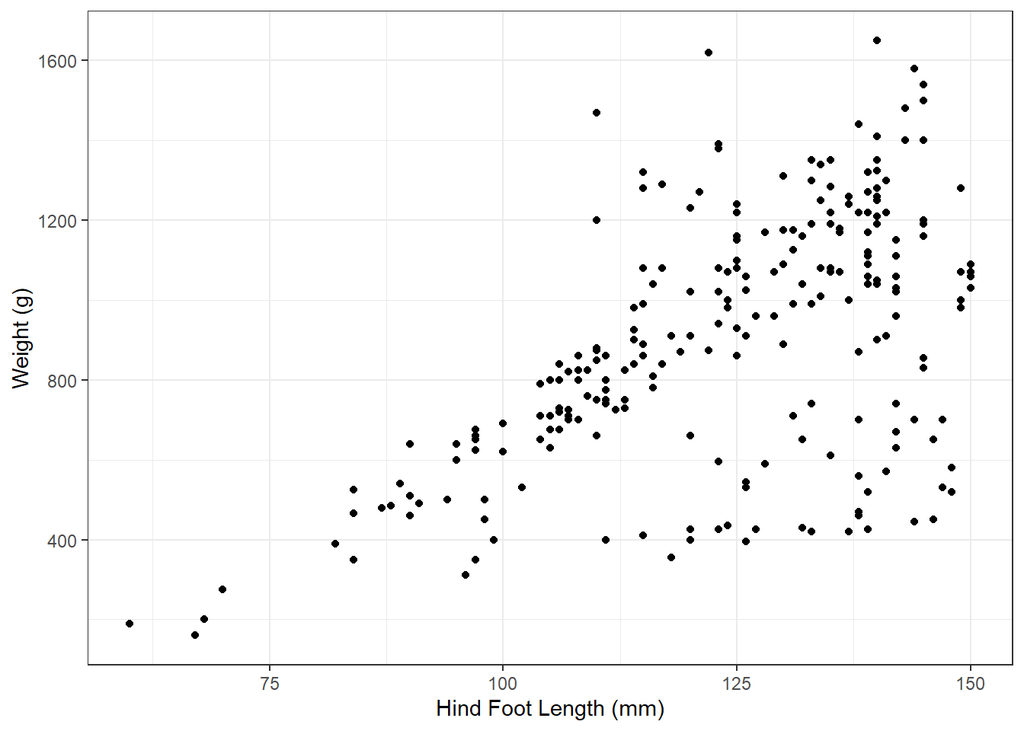

Figure 3.3: Snowshoe hare hind foot lenght plotted against body weight

```r
ggplot(juveniles, aes(x = hindft, y = weight)) +
  geom_point() +
  xlab("Hind Foot Length (mm)") +
  ylab("Weight (g)") +
  theme_bw()
```

Trying out a linear model relating hind foot length to body weight in juvenile snowshoe hares.

```r
hare_mod = lm(weight ~ hindft, data = juveniles)
summary(hare_mod)
```

```
##
## Call:
## lm(formula = weight ~ hindft, data = juveniles)
##
## Residuals:
##    Min     1Q Median     3Q    Max
## -661.1 -108.2   17.0  164.2  737.5
##
## Coefficients:
##              Estimate Std. Error t value Pr(>|t|)
## (Intercept) -279.3419   115.4811  -2.419   0.0163 *
## hindft         9.5234     0.9283  10.259   <2e-16 ***
## ---
## Signif. codes:  0 '***' 0.001 '**' 0.01 '*' 0.05 '.' 0.1 ' ' 1
##
## Residual standard error: 263.9 on 247 degrees of freedom
##   (129 observations deleted due to missingness)
## Multiple R-squared:  0.2988, Adjusted R-squared:  0.2959
## F-statistic: 105.2 on 1 and 247 DF,  p-value: < 2.2e-16
```

```r
hm = tidy(hare_mod)
hm2 = glance(hare_mod)
```

Now, examining correlation between hind foot length and weight for juvenile hares.

```r
hare_cor = cor.test(juveniles$hindft, juveniles$weight)
hare_cor
```

```
##
##  Pearson's product-moment correlation
##
## data:  juveniles$hindft and juveniles$weight
## t = 10.259, df = 247, p-value < 2.2e-16
## alternative hypothesis: true correlation is not equal to 0
## 95 percent confidence interval:
##  0.4530683 0.6282259
## sample estimates:
##       cor
## 0.5465982
```

Diagnostic plots for the linear model

```r
plot(hare_mod)
```

[output not shown]

# 4 Summary

In conclusion, the most juvenile hares were caught early in the study, and fewer were caught in subsequent years. Mean male body weight was larger than mean female body weight, but the difference in these means was small. Body weight appeared positively correlated to hind foot length in juvenile snowshoe hares, though it is not clear that a ordinary-least-squares linear model is appropriate for these data.

# 5 Citations

Kielland, K., F.S. Chapin, R.W. Ruess, and Bonanza Creek LTER. 2017. Snowshoe hare physical data in Bonanza Creek Experimental Forest: 1999-Present ver 22. Environmental Data Initiative. https://doi.org/10.6073/pasta/03dce4856d79b91557d8e6ce2cbcdc14